# A14.10 曲げ剪断応力。開断面と閉断面。剪断中心。

$$I_n = 0.63316 \times .0474^2 + .02782 \times .9989^2 = .02919$$

中立軸 $n-n$ に垂直な、与えられた外力剪断荷重の成分は、以下に等しい。

式(13)より、

$$q = - \frac{V_n}{I_n} \Sigma z_n A$$

点(b)における剪断流：- 中立軸から部分(1)の図心までの距離は $z_n = -0.0466 \text{ in.}$ に等しい。 したがって、

$$q_b = - \frac{7130}{.02919} (1 \times 0.1) (-0.0466) = 1135 \text{ lb./in.}$$

点(c)における剪断流：- $z_n = 0.1868 \text{ in.}$

$$q_c = 1135 - \frac{7130}{.02919} (1.4 \times 0.1) .1868$$

$$= 1135 - 6390 = -5255 \text{ lb./in.}$$

### 方法3による解法 - （ $k$ 方法）

この方法では、図心 $X$ および $Z$ 軸に関する断面特性のみが必要である。これらの特性は、以前に Table A14.3 で計算されたように、以下の通りである。

$$I_x = 0.6035, \quad I_z = 0.0574, \quad I_{xz} = -0.1305$$

式(14)からの剪断流方程式は、

$$q = - (k_3 V_x - k_1 V_z) \Sigma x A - (k_2 V_z - k_1 V_x) \Sigma z A \qquad \text{--- (16)}$$

$$k_1 = \frac{I_{xz}}{I_x I_z - I_{xz}^2} = \frac{-0.1305}{0.6035 \times .0574 - (-0.1305)^2}$$

$$= \frac{-0.1305}{.01762} = -7.406$$

$$k_2 = \frac{I_z}{I_x I_z - I_{xz}^2} = \frac{0.0574}{.01762} = 3.257$$

$$k_3 = \frac{I_x}{I_x I_z - I_{xz}^2} = \frac{0.6035}{0.01762} = 34.25$$

$10,000$ の外力剪断荷重を $x$ および $z$ 成分に分解すると、以下を得る。

$$V_x = 10000 \sin 30^\circ = 5000 \text{ lb.}$$

$$V_z = 10000 \cos 30^\circ = 8667 \text{ lb.}$$

$V_x$ 、 $V_z$ および $k$ の値を式(16)に代入すると、以下を得る -

$$q = - [34.25 \times 5000 - (-7.406 \times 8667)] \Sigma x A - [3.257 \times 8667 - (-7.406 \times 5000)] \Sigma z A$$

これより、

$$q = - 235438 \Sigma x A - 65258 \Sigma z A$$

点(b)における剪断流 部分(1)について、 $x = -0.45 \text{ in.}$ 、 $z = 1.45 \text{ in.}$

$$A = 1 \times 0.1 = .1$$

代入すると、

$$q_b = - 235438 (-0.45) 0.1 - 65258 \times 1.45 \times 0.1$$

$$= 10597 - 9462 = 1135 \text{ lb./in.}$$

点(c) 部分(2)について、 $x = 0$ 、 $z = 0.7$ 、 $A = 1.4 \times .1 = .14$

$$= 1135 - 0 - 6395 = -5260 \text{ lb./in.}$$

### 一般的なコメント

著者は、方法1および2で必要となる追加の角度や断面特性の計算を回避できるため、解法方法3を好む。さらに、飛行機の翼、胴体、およびその他の主要な構造ユニットの剪断力とモーメントを計算する際には、これらの剪断力とモーメントを従来の $X$ $Y$ $Z$ 軸に言及することが便利であり、したがって、これらの値はさらに分解することなく方法3で使用できる。多くの飛行機応力解析報告書の調査から、ほとんどの飛行機会社の技術者は方法3を使用することを好むようである。

### A14.9 一定の剪断流ウェブを持つ梁

[figure not shown]

Fig. A14.29

Fig. A14.29 は、重いフランジ部材と湾曲した薄いウェブで構成された梁を示している。 $X-X$ 軸まわりの曲げに対して、梁の圧縮側のウェブは非常に小さな圧縮応力しか吸収しない。これは、特にウェブの曲率が小さい場合、低い応力下でウェブの座屈が発生するためである。引張側では、ウェブはより効果的であるが、フランジ面積が比較的大きい場合、ウェブによって負担される全曲げ引張応力の割合は、引張フランジによって負担される割合と比較して小さい。したがって、薄いウェブで接続された個々のフランジ部材で構成される梁については、フランジが縦方向の全曲げ抵抗を発達させると仮定されることが多く、これはしたがって、特定のウェブ上の剪断流が一定であることを意味する。換言すれば、剪断流方程式

$$q = \frac{V_z}{I_x} \int z \, dA$$

において、ウェブの面積を無視すると、フランジ部材間で $q$ は一定となる。

## 一定の剪断流力系の合力

Fig. A14.29 は、下向きの剪断荷重（図示せず）を支持し、ねじれを伴わずに $x-x$ 軸まわりに曲げを引き起こすと仮定された梁を示している。2つのフランジが曲げ抵抗のすべてを発達させると仮定すると、剪断流 $q$ はウェブ上で一定であり、仮定された外部の下向き荷重と釣り合うようにウェブに沿って上向きに作用する。この抵抗する剪断流力系の合力は、この梁断面の剪断中心の横方向の位置を与える。したがって、問題はこの剪断流系の合力を求めることである。

$q =$ ウェブに沿った1インチあたりの荷重（一定）とする。  
$R = q$ 力系の合力とする。  
初等力学より、

$$R = \sqrt{\Sigma q_x^2 + \Sigma q_y^2}$$

ここで、 $q_x$ と $q_y$ はウェブに沿った $q$ 力の $x$ および $y$ 成分である。 $q$ は一定であるため、 $\Sigma q_x$ はゼロであり、したがって、

$$R = \Sigma q_y = q h \qquad \text{--- (17)}$$

式(17)は、一定の流れ力系の合力の大きさは、剪断流 $q$ に剪断流系の両端を結ぶ直線距離を掛けたものに等しいことを示している。

$\Sigma q_x$ はゼロであるため、合力の方向は、ウェブの両端を結ぶ直線に平行である。

合力の位置は、モーメントの原理、すなわち、任意の点まわりの合力のモーメントは、同じ点まわりの元の力系のモーメントに等しくなければならないという原理を用いて求められる。Fig. A14.29 において、点 $(0)$ をモーメント中心と仮定する。

このとき

$$R e = q L r$$

しかし

$$R = q h$$

したがって、

$$e = \frac{q L r}{q h} = \frac{L r}{h} \qquad \text{--- (18)}$$

式(18)において、項 $L r$ は面積 $(A)$ の2倍に等しく、ここで面積 $(A)$ は、モーメント中心 $(0)$ から剪断流力系の端部へ直線を描くことによって形成される囲まれた面積である。したがって、

$$e = \frac{2 A}{h} \qquad \text{--- (19)}$$

したがって、剪断中心は点 $(0)$ の左側距離 $e$ に位置し、ねじれを排除するためには、外力剪断荷重はこの点を通って作用しなければならない。

### 例題 - 一定流力系の合力

Fig. A14.30 は、点 A B C D E を通る $q = 10 \text{ lb.}$ / インチの一定流力系を示している。この力系の合力が必要である。

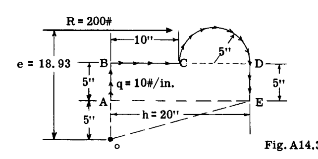

Fig. A14.30

#### 解答: -

力系の始点と終点の間に閉合線を描く（線 AE）。この閉合線の長さ $h$ は20インチである。

式(17)より、

$$R = q h = 10 \times 20 = 200 \text{ lb.}$$

合力の方向は、線 AE に平行、すなわちこの問題では水平である。 $R$ の位置を求めるために、任意の点 $(0)$ まわりのモーメントをとる。点 $(0)$ から点 A および E へ線を描く。囲まれた面積 $(A)$ は、以下に等しい。

$$5 \times 10 + 5 \times 10 + .5 \pi \times 5^2 + 10 \times 5 = 189.3 \text{ sq. in.}$$

式(19)より、

$$e = \frac{2 A}{h} = \frac{2 \times 189.3}{20} = 18.93 \text{ in.}$$

Fig. A14.30 は、 $(0)$ から距離 $e$ に作用し、線 AE に平行な $200 \text{ lb.}$ の合力を示している。

## A14.10 フランジ部材間に一定の剪断流を持つ梁の例題

### 例題 1. 1つの軸に対して対称な梁断面

Fig. A14.31 は、薄いシートで接続された 8 つのフランジ部材で構成される開断面梁を示しており、ウェブと壁を形成している。

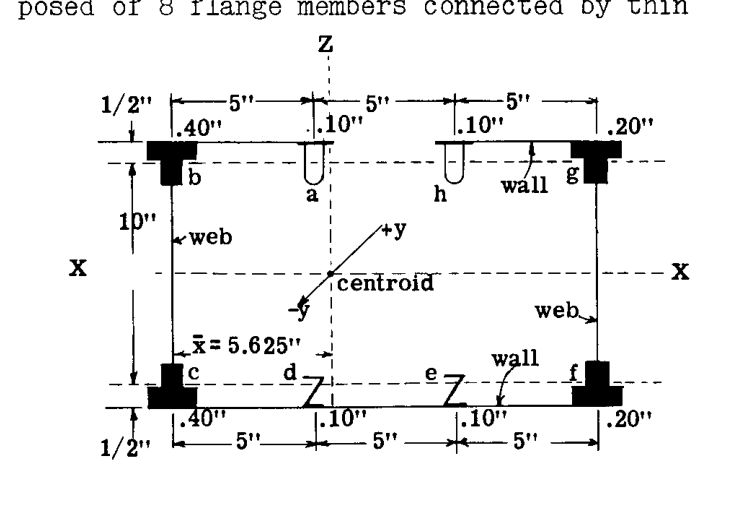

Fig. A14.31

フランジ部材には $a$ から $h$ までの番号が付けられており、それぞれの面積が図に示されている。ウェブと壁は曲げ抵抗を発生させず、したがって隣接するフランジ部材間の剪断流は一定であると仮定される。問題は、この梁断面の剪断中心を決定することである。

#### 解答: -

梁断面は $X$ 軸に関して対称であるため、図心の $X$ および $Z$ 軸も主軸であり、慣性相乗モーメント $I_{xz}$ はゼロである。

対称性による梁断面図心の垂直位置は、上部フランジと下部フランジの中間にある。

図心の水平位置を求めるために、左端または線 $bc$ まわりのフランジ面積のモーメントをとる。

$$\bar{x} = \frac{\Sigma A x}{\Sigma A} = \frac{0.4 \times 15 + 0.2 \times 10 + 0.2 \times 5}{1.6} = 5.625 \text{ in.}$$

図心の $x$ および $y$ 軸に関する断面二次モーメントは以下の通りである。-

$$I_x = \Sigma A z^2 = (0.8 \times 5^2) \times 2 = 40 \text{ in}^4$$

$$I_z = 0.8 \times 5.625^2 + 0.2 \times 0.625^2 + 0.2 \times 4.375^2 + 0.4 \times 9.375^2 = 64.4 \text{ in}^4$$

#### 剪断中心の水平位置: -

剪断中心の水平位置は、ねじれを伴わない $xx$ 軸まわりの曲げによる剪断流系の図心と一致する。簡単にするために、剪断流値の大きな小数の値を排除するために、外力の上向き剪断荷重 $V_z = 100 \text{ lb.}$ が仮定され、この外力荷重に対する内部の抵抗剪断流系が計算される。

式(8)より、

$$q_y = - \frac{V_z}{I_x} \Sigma z A$$

$V_z$ と $I_x$ の値を代入すると、

$$q_y = - \frac{100}{40} \Sigma z A = -2.5 \Sigma z A$$

2つの点 $(a)$ または $(h)$ のいずれからでも計算を開始することができる。これらの点は自由縁であり、したがって $q_y$ はゼロである。この解法では、点 $(a)$ の自由縁から開始し、梁断面を反時計回りに進む。各フランジ部材の面積は、各フランジ面積の図心と一致する点に集中している。 $q$ 値を解く際には、下付き文字 $y$ は省略され、剪断流がどの点で計算されているかを示すために、フランジの文字を使用した下付き文字が使用される。

$$q_{ab} = - 2.5 \Sigma_a z A = -2.5 \times 5 \times 0.1 = -1.25 \text{ lb./in.}$$

下付き文字の最初の文字は、剪断流 $q$ が計算されているフランジ部材を指し、2番目の文字は、特定のフランジ部材のどの隣接する側にあるかを示している。したがって、 $q_{ab}$ はフランジ $(a)$ におけるが、 $(b)$ に向かう側での剪断流を意味する。

$$q_{ab} = q_{ba} = -1.25 \text{ （追加のフランジ面積が加わらないため、剪断流はシート ab 上で一定である）}$$

$$q_{bc} = q_{ba} - 2.5 \Sigma_b z A = -1.25 - 2.5 \times 5 \times 0.4 = -6.25 \text{ lb./in.}$$

$$q_{cb} = -6.25$$

$$q_{cd} = q_{cb} - 2.5 \Sigma_c z A = -6.25 - 2.5 \times (-5 \times 0.4) = -1.25$$

$$q_{dc} = q_{cd} = -1.25$$

$$q_{de} = q_{dc} - 2.5 \Sigma_d z A = -1.25 - 2.5 \times (-5 \times 0.1) = 0$$

$$q_{ed} = q_{de} = 0$$

$$q_{ef} = 0 - 2.5 \Sigma_e z A = 0 - 2.5 \times (-5 \times 0.1) = 1.25$$

$$q_{fe} = q_{ef} = 1.25$$

$$q_{fg} = 1.25 - 2.5 \Sigma_f z A = 1.25 - 2.5 \times (-5 \times 0.2) = 3.75$$

$$q_{gf} = q_{fg} = 3.75$$

$$q_{gh} = 3.75 - 2.5 \Sigma_g z A = 3.75 - 2.5 \times 5 \times 0.2 = 1.25$$

$$q_{hg} = q_{gh} = 1.25$$

$$q_{ha} = 1.25 - 2.5 \Sigma_h z A = 1.25 - 2.5 \times 5 \times 0.1 = 0 \text{ （h における自由縁と一致する）}$$

各剪断流の符号または方向は、剪断流方程式の導出において説明されているように、 $y$ 方向の剪断流に対するものである。現在の手順は、断面の平面、または $xz$ 平面における剪断流の方向を決定することである。開始点、すなわちシートパネル $ab$ においてこの方向を決定することだけが必要である。この方向を決定する最も確実な方法は、Fig. A14.31 に示すように、フランジ部材 $(a)$ の単純な自由体図を描くことである。カット面上の剪断流は $q_{y(ab)} = -1.25$ であり、この値は自由体上に示されている。Art. A14.6 の最後で与えられた単純な規則により、断面の平面における剪断流も共通の境界線に向かって方向付けられ、したがって $q_{x(ab)}$ は Fig. A14.31 に示すような方向を持つ。

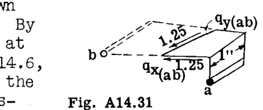

Fig. A14.31(a)

断面上の剪断流の方向は、元の計算で符号が変わるまでこの方向に継続し、これはしたがって剪断流の方向が逆転することを意味する。Fig. A14.32 は、矢印の頭で示された方向を持つ剪断流パターンのプロットを示している。

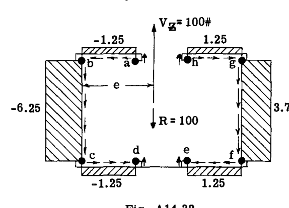

Fig. A14.32

結果は、 $\Sigma F_x = 0$ および $\Sigma F_z = 0$ に関して静的平衡が存在するかどうかを確認するためにチェックされる。

$$\Sigma F_z = 100 \text{ (外力荷重)} - 10 \times 6.25 - 10 \times 3.75 + 1.25 \times 0.5 \times 4 - 1.25 \times 0.5 \times 4 = 0 \text{ (確認)}$$

$$\Sigma F_x = -5 \times 1.25 + 5 \times 1.25 - 5 \times 1.25 + 5 \times 1.25 = 0 \text{ (確認)}$$

Fig. A14.32 における剪断流力系は、断面をねじれを伴わずに $xx$ 軸まわりに曲げさせる。この系の合力は、 $z$ 方向に作用する $100 \text{ lb.}$ である。この合力の位置は、したがって剪断中心の横方向の位置を特定する。

剪断流系のモーメントを、たとえば $(c)$ などの任意の点まわりで等しくし、同じ点まわりの合力のモーメントを求めると、以下を得る。-

$$100 e = 10 \times 3.75 \times 15 - 1.25 \times 0.5 \times 2 \times 5 - 1.25 \times 0.5 \times 2 \times 10 + 1.25 \times 0.5 \times 2 \times 15$$

したがって、

$$e = 562.5 / 100 = 5.625 \text{ インチ}$$

したがって、剪断中心は、線 $bc$ の右側 $5.625$ インチの垂直線上にある。

### 剪断中心の垂直位置の計算

便宜上、以前と同様に、剪断荷重 $V_x = 100 \text{ lb.}$ を仮定し、ねじれを伴わない $zz$ 軸まわりの曲げに抵抗するための抵抗剪断流系を計算する。この剪断流系の合力は、剪断中心の垂直位置を与える。剪断流方程式は、

$$q_y = - \frac{V_x}{I_z} \Sigma x A = - \frac{100}{64.4} \Sigma x A = -1.55 \Sigma x A$$

再び、 $q_y = 0$ であるフランジ $(a)$ に隣接する自由縁から開始する。

$$q_{ab} = - 1.55 \Sigma_a x A = -1.55 (-0.625 \times 0.1) = 0.0971 \text{ lb./in.}$$

$$q_{ba} = q_{ab} = 0.0971$$

$$q_{bc} = 0.0971 - 1.55 \Sigma_b x A = 0.0971 - 1.55 (-5.625 \times 0.4) = 3.592$$

$$q_{cb} = q_{bc} = 3.592$$

$$q_{dc} = 7.087$$

$$q_{de} = 7.087 - 1.55 (-0.625 \times 0.1) = 7.184$$

$$q_{ed} = 7.184$$

$$q_{ef} = 7.184 - 1.55 \times 4.375 \times 0.1 = 6.504$$

$$q_{fe} = 6.504$$

$$q_{fg} = 6.504 - 1.55 \times 9.375 \times 0.2 = 3.589$$

$$q_{gf} = 3.589$$

$$q_{gh} = 3.589 - 1.55 \times 9.375 \times 0.2 = 0.674$$

Fig. A14.33 は、プロットされた剪断流結果を示している。計算された剪断流の符号は、 $y$ 方向の剪断流に対するものである。フランジ部材 $(a)$ の自由体の単純な考慮は、断面の平面における剪断流の符号または方向を与える。したがって、Fig. A14.34 において、 $q_y$ が正のとき、 $q_x$ は示されているように作用しなければならない。

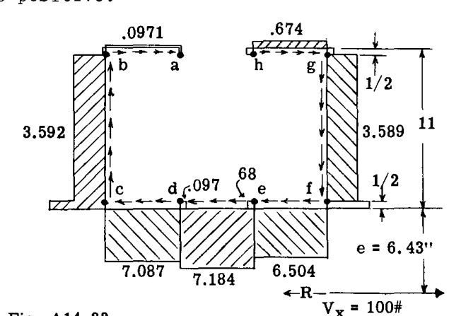

Fig. A14.33

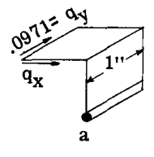

Fig. A14.34

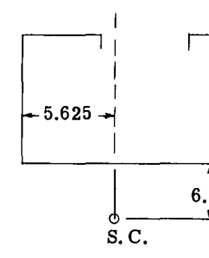

Fig. A14.35

$\Sigma F_z = 0$ および $\Sigma F_x = 0$ であるかどうかの確認: -

$$\Sigma F_z = 3.592 \times 10 - 3.589 \times 10 + .5 \times .0971 - .5 \times .0971 + 5 \times .674 - .5 \times .674 + .5 \times .0971 - .5 \times .674 - .5 \times 6.504 + .5 \times 7.087 = 0 \text{ (確認)}$$

$$\Sigma F_x = 100 + 5 \times .0971 + 5 \times .674 - 5 (7.087 + 7.184 + 6.504) = 0 \text{ (確認)}$$

内部剪断流系の合力 $R$ は、左に向かって作用する $100 \text{ lb.}$ の水平力である。合力の位置を求めるために、点 $(c)$ の $0.5$ インチ下の点まわりのモーメントをとる。

$$R e = \Sigma M$$

$$100 e = 5 (.0971 + .674) 11 + 10 \times 3.589 \times 15 + .5 \times .0971 \times 5 - (.5 \times .674 \times 10) + .5 \times .674 \times 15 + .5 \times 6.504 \times 15 + .5 \times .674 \times 10 - (.5 \times .0971 \times 5)$$

$$100 e = 643$$

$$e = 643/100 = 6.43 \text{ インチ}$$

Fig. A14.35 は、与えられた梁断面に対する結果としての剪断中心位置を示している。

### 例題 2. 非対称梁断面

Fig. A14.36 は、4つのフランジを持つ梁断面を示している。各フランジの面積はフランジに隣接して示されている。外力剪断荷重 $V$ は $141.14 \text{ lb.}$ に等しく、示されている方向に作用する。問題は、断面がねじれを伴わずに曲がるように、 $V$ の作用線を求めることである。

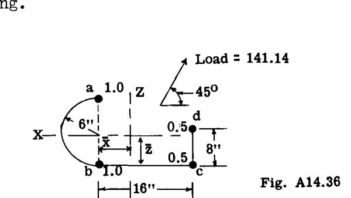

Fig. A14.36

#### 解答: -

この問題を解決するために、方法 (3) が使用される。  
図心 $x$ および $z$ 軸を配置するために: -

$$\bar{z} = \frac{\Sigma A x}{\Sigma A} = \frac{1 \times 12 + 0.5 \times 8}{3} = 5.333 \text{ in.}$$

$$\bar{x} = \frac{\Sigma A z}{\Sigma A} = \frac{(0.5 + 0.5) 16}{3} = 5.333 \text{ in.}$$

$I_x$ 、 $I_z$ および $I_{xz}$ の計算 –

$$I_x = \Sigma A z^2 = .5 (5.333^2 + 2.667^2) + 1 (5.333^2 + 6.667^2) = 90.667$$

$$I_z = \Sigma A x^2 = 1 (10.667^2) + 2 (5.333^2) = 170.667$$

$$I_{xz} = \Sigma A xz = 1 \times 6.667 (-5.333) + 1 (-5.333) (-5.333) + 0.5 \times 10.667 \times 2.667 + 0.5 \times 10.667 (-5.333) = -21.333$$

定数 $k_1$ 、 $k_2$ および $k_3$ が決定される -

$$k_1 = \frac{I_{xz}}{I_x I_z - I_{xz}^2} = \frac{-21.333}{90.667 \times 170.667 - 21.333^2}$$

$$= \frac{-21.333}{15019} = -.00142$$

$$k_2 = \frac{I_z}{I_x I_z - I_{xz}^2} = \frac{170.667}{15019} = 0.01136$$

$$k_3 = \frac{I_x}{I_x I_z - I_{xz}^2} = \frac{90.667}{15019} = 0.006037$$

与えられた $141.14$ の剪断荷重を $z$ および $x$ 成分に分解すると、以下を得る。

$$V_z = 141.14 \times \sin 45^\circ = 100 \text{ lb.}$$

$$V_x = 141.14 \times \cos 45^\circ = 100 \text{ lb.}$$

式(14)より -

$$q_y = - (k_3 V_x - k_1 V_z) \Sigma x A - (k_2 V_z - k_1 V_x) \Sigma z A$$

代入すると

$$q_y = - [.006037 \times 100 - (-.00142 \times 100)] \Sigma x A - [.01136 \times 100 - (-.00142 \times 100)] \Sigma z A$$

これより

$$q_y = - 0.7457 \Sigma x A - 1.278 \Sigma z A$$

部材の自由縁側で $q_y$ がゼロであるフランジ部材 $(a)$ から開始する。

$$q_{ab} = - 0.7457 \times 1 (-5.333) - 1.278 \times 1 \times 6.667 = -4.544$$

$$q_{ba} = q_{ab} = -4.544$$

$$q_{bc} = -4.544 - 0.7457 \times 1 (-5.333) - 1.278 \times 1 (-5.333) = 6.249 \text{ lb./in.}$$

$$q_{cb} = q_{bc} = 6.249$$

$$q_{cd} = 6.249 - 0.7457 \times 0.5 \times 10.667 - 1.278 \times 0.5 (-5.333) = 5.680$$

$$q_{dc} = q_{cd} = 5.680$$

$$q_{da} = 5.680 - 0.7457 \times .5 \times 10.667 - 1.278 \times 0.5 \times 2.667 = 5.680 - 3.977 - 1.704 = 0$$

（ $q_y$ がゼロでなければならない $d$ における自由縁と一致する。）

Fig. A14.37 は、結果としての剪断流抵抗パターンを示している。断面の平面における剪断流の方向は、Fig. A14.37a におけるストリンガー $(a)$ の簡単な自由体図によって、フランジ部材 $(a)$ におけるウェブで決定される。

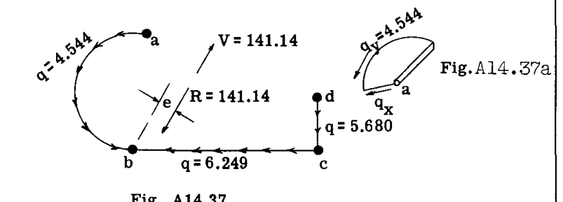

Fig. A14.37

各々が100に等しいかどうかを確認するために、 $\Sigma F_x$ と $\Sigma F_z$ をチェックする。

$$\Sigma F_x = - 6.249 \times 16 = -99.99 \text{ (} V_x = 100 \text{ を確認)}$$

$$\Sigma F_z = -12 \times 4.544 - 8 \times 5.68 = -99.94 \text{ (} V_z = 100 \text{ を確認)}$$

内部抵抗剪断流系の合力は、以下に等しい。

$$\sqrt{100^2 + 100^2} = 141.14 \text{ lb.}$$

この合力を配置するために、モーメントの原理を使用する。点 $(b)$ をモーメント中心としてとると、

$$141.14 e = 8 \times 5.68 \times 16 - 4.544 \times 36 \pi$$

したがって、

$$e = \frac{212}{141.14} = 1.50 \text{ インチ}$$

したがって、外力荷重は Fig. A14.37 に示すように $(b)$ から距離 $e = 1.50"$ で作用しなければならない。そのように配置された荷重は、断面の剪断中心を通過する。剪断中心の位置を得るために、梁上の別の荷重を仮定することができ、抵抗剪断流系の合力の作用線が上記で求められた合力と交差する場所が、単一の点として剪断中心を特定する。剪断中心の位置が望まれる場合、個別に作用する単位 $V_z$ および $V_x$ を仮定し、2つの個別の剪断流力系から剪断中心の水平および垂直位置を見つけることが便利である。

### A14.11 中立軸方法による剪断中心の配置

曲げを受ける梁においては、梁上の外力荷重の異なるそれぞれの平面に対して、明確な中立軸の位置が存在する。中立軸に関する剪断流方程式は、

$$q_y = - \frac{V_n}{I_n} \Sigma z_n A \qquad \text{--- (20)}$$

ここで、

- $V_n =$ 中立軸に垂直に分解された剪断力
- $I_n =$ 中立軸に関する断面二次モーメント
- $z_n =$ 中立軸までの距離

非対称断面の剪断中心位置を見つけるにあたり、 $Z$ および $X$ 軸が中立軸であると仮定し、式(20)によって各軸まわりの曲げに対する剪断流系を求めることが便利である。これらの剪断流力系のそれぞれの合力は剪断中心を通過するため、これら2つの合力の交点が剪断中心を特定する。

#### 例題

前条で使用されたものと同じ梁断面（Fig. A14.36 参照）を使用して、中立軸方法を説明する。

Fig. A14.38 は、図心軸が描かれた断面を示している。 $X$ 軸は今、まだ未知の外力荷重の平面に対する中立軸として仮定される。この未知の外力荷重が $X$ 中立軸に垂直に分解されたとき、 $100 \text{ lb.}$ 、すなわち $V_z = 100$ の値を与えるとさらに仮定する。前条より、 $I_x = 90.667$ である。

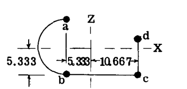

Fig. A14.38

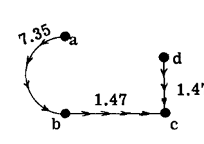

Fig. A14.39

$X$ 軸が中立軸として仮定されているため、式(20)は以下のように書くことができる。

$$q_y = - \frac{V_z}{I_x} \Sigma z A$$

したがって、

$$q_{ab} = - \frac{100}{90.667} \times 6.667 \times 1.0 = -7.35 \text{ lb./in.}$$

$$q_{bc} = - 7.35 - \frac{100}{90.667} \times (-5.333) \times 1 = -1.47$$

$$q_{cd} = -1.47 - \frac{100}{90.667} (-5.333) 0.5 = 1.47$$

Fig. A14.39 は、結果としての剪断流値を示している。

$$\Sigma F_x = 1.47 \times 16 = 23.52 \text{ lb.}$$

$$\Sigma F_z = 7.35 \times 12 + 8 \times 1.47 = 99.96 \text{ lb. (確認)}$$

$$R = \sqrt{100^2 + 23.52^2} = 103 \text{ lb.}$$

$$\tan \theta = 23.52/100 = .2352$$

したがって、 $\theta = 13^\circ - 16'$

$e =$ 合力 $R$ から点 $b$ までの距離とする。

合力 $(b)$ まわりのモーメントを剪断流系の $(b)$ まわりのモーメントと等しくすると、

$$e = - \frac{644}{103} = -6.25 \text{ インチ}$$

Fig. A14.40 は、合力の位置を示している。合力がこの合力の作用線上にあることを我々は知っている。したがって、我々は剪断中心を明確に配置する前に、剪断中心を通過する別の合力を得なければならない。したがって、我々は今、 $Z$ 図心軸が中立軸であり、外力荷重系の分解が剪断力 $V_x = 100 \text{ lb.}$ を与えると仮定する。

$$q_y = - \frac{V_x}{I_z} \Sigma x A, \qquad I_z = 170.667$$

$$q_{ab} = - \frac{100}{170.667} \times (-5.333) 1 = 3.125 \text{ lb./in.}$$

$$q_{bc} = 3.125 - \frac{100}{170.667} (-5.333) 1 = 6.25 \text{ lb./in.}$$

$$q_{cd} = 6.25 - \frac{100}{170.667} (0.5) (10.667) = 3.13$$

Fig. A14.41 は、剪断流の結果を示している。

$$\Sigma F_x = -6.25 \times 16 = -100 \text{ lb.}$$

$$\Sigma F_z = -8 \times 3.13 + 12 \times 3.125 = 12.5 \text{ lb.}$$

$$R = \sqrt{100^2 + 12.5^2} = 100.8$$

$$\tan \theta = \frac{12.5}{100} = .125$$

$(b)$ まわりのモーメントをとり、 $(e)$ を合力 $R$ への距離と等しくする。

$$100.8 e = 3.125 \times \pi \times 6^2 + 3.13 \times 8 \times 16$$

$$e = 753 / 100.8 = 7.47 \text{ in.}$$

Fig. A14.40 は、この合力の位置を示している。それが以前の合力と交差する場所が、剪断中心の位置を与える。

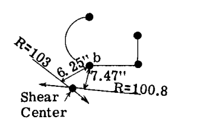

Fig. A14.40

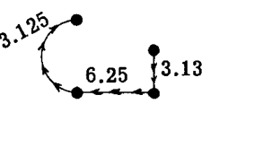

Fig. A14.41

## A14.12 問題

1. Fig. A14.42 は、線 a-a および a-b 上で接着された木製梁の断面を示している。梁は垂直剪断力 $V = 2400 \text{ lb.}$ を受ける。断面 a-a および a-b における剪断応力を決定せよ。梁断面における最大剪断応力を求めよ。

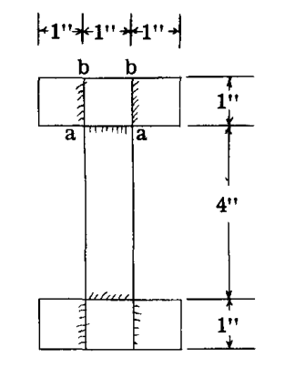

Fig. A14.42

2. Fig. A14.43 は、示されているように剪断中心を通って作用する $1000 \text{ lb.}$ の荷重を受ける Z 断面を示している。3つの異なる方法によって、断面 a-a および b-b における剪断応力を求めよ。

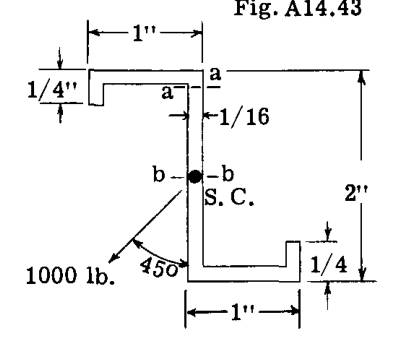

Fig. A14.43

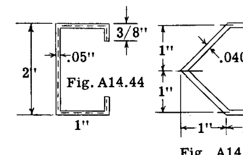

Fig. A14.44

3. Figs. A14.44 から A14.46 に示されている梁断面について、水平図心軸まわりの曲げに対する剪断流図および剪断中心位置を決定せよ。

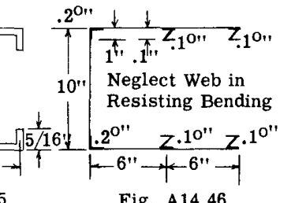

Fig. A14.46

4. Figs. A14.47 および A14.48 における梁断面の剪断中心位置を決定せよ。フランジ部材が曲げ応力抵抗のすべてを発達させると仮定せよ。

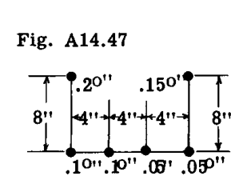

Fig. A14.47

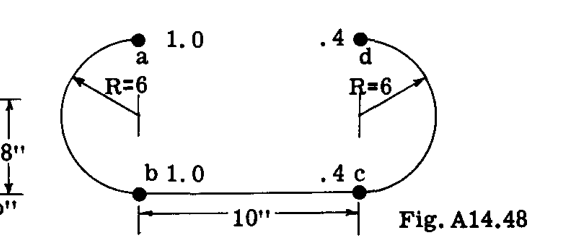

Fig. A14.48

5. Fig. A14.49 の梁断面に対する剪断中心を決定せよ。曲げにおいて効果的であるのは、8つのストリンガーのみであると仮定せよ。ストリンガー (a) および (b) の面積 $= \text{各 2 sq. in.}$ である。他のすべてのストリンガーは各 $1 \text{ sq. in.}$ である。

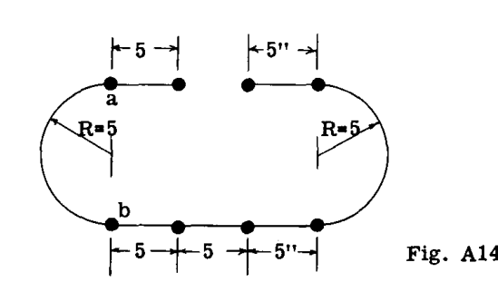

Fig. A14.49

6. Fig. A14.50 の非対称梁断面の剪断中心を決定せよ。4つのストリンガーを接続するシートは効果がないと仮定せよ。ストリンガーの面積は図に示されている。

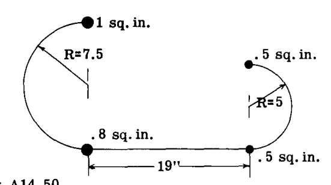

Fig. A14.50

7. Fig. A14.51 において、外殻構造はねじりモーメント $M = 50,000 \text{ in. lb.}$ を受ける。破線で示されている外殻スキンは切り取られており、したがってねじりモーメントは、2つの湾曲したシートエレメント ac および bd 上の一定の剪断流によって抵抗される。剪断流の値を決定せよ。

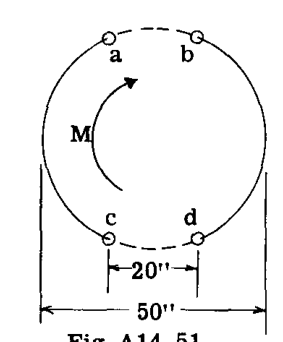

Fig. A14.51

8. Fig. A14.52 における一定流力系の点 (0) まわりのモーメントを決定せよ。また、この力系の合力を求めよ。

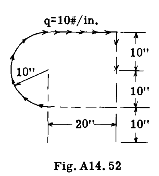

Fig. A14.52

9. Fig. A14.53 において、4つのストリンガー a, b, c, および d は同じ面積を持つ。曲げ応力に抵抗するにあたり、ウェブは効果がないと仮定せよ。ねじれを伴わずに水平軸まわりの曲げを生成するための距離 (e) を決定せよ。

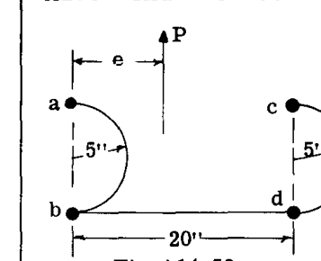

Fig. A14.53

10. Fig. A14.54 の翼セル梁断面について、剪断中心の位置を決定せよ。曲げにおいてウェブおよび壁は効果がないと仮定せよ。

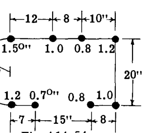

Fig. A14.54